# Group 13 GLM - Ikea Dataset

Group 13

14/03/2022

# Introduction and Cleaning the Data

The dataset contains information on IKEA furniture from Saudi Arabia, a column has been added indicating if the piece of furniture costs more than 1000 Riyals.

```
##   X  item_id                   category price sellable_online other_colors
## 1 1 60406785                     Chairs   149            TRUE           No
## 2 2 99221446             Tables & desks  5465            TRUE           No
## 3 3 29221765 Bookcases & shelving units   660            TRUE           No
## 4 4 20403374          Sofas & armchairs   395            TRUE          Yes
## 5 5 89256262                     Chairs  1895            TRUE          Yes
## 6 6 50165079          Nursery furniture   375            TRUE           No
##   depth height width thousandRiyals
## 1    44    103    52              N
## 2    NA     NA    NA              Y
## 3    35    176    86              N
## 4    NA     NA    NA              N
## 5   164    104   117              Y
## 6    53     93    52              N
```

The summary of the data indicates that there is a lot of NA values in the height, depth and width columns.

```
##        X            item_id           category             price
##  Min.   :  1.0   Min.   :   91415   Length:500         Min.   :   3.0
##  1st Qu.:125.8   1st Qu.:20344743   Class :character   1st Qu.: 168.8
##  Median :250.5   Median :49284139   Mode  :character   Median : 457.0
##  Mean   :250.5   Mean   :48073026                      Mean   : 991.1
##  3rd Qu.:375.2   3rd Qu.:70414743                      3rd Qu.:1245.0
##  Max.   :500.0   Max.   :99305158                      Max.   :8551.0
##
##  sellable_online other_colors           depth            height
##  Mode :logical   Length:500         Min.   :  1.00   Min.   :  3.0
##  FALSE:1         Class :character   1st Qu.: 37.00   1st Qu.: 68.0
##  TRUE :499       Mode  :character   Median : 46.00   Median : 83.0
##                                     Mean   : 53.34   Mean   :102.3
##                                     3rd Qu.: 60.00   3rd Qu.:123.8
##                                     Max.   :252.00   Max.   :251.0
##                                     NA's   :191      NA's   :146
##      width       thousandRiyals
##  Min.   :  2.0   Length:500
##  1st Qu.: 56.0   Class :character
##  Median : 80.0   Mode  :character
##  Mean   :101.1
##  3rd Qu.:134.2
##  Max.   :367.0
##  NA's   :80
```

To solve this, I computed the mean of the depth, height and width by the category and replaced the NA’s by this value shown below.

```
## # A tibble: 500 x 10
## # Groups:   category [17]
##        X  item_id category price sellable_online other_colors depth height width
##    <int>    <int> <chr>    <dbl> <lgl>           <chr>        <dbl>  <dbl> <dbl>
##  1     1 60406785 Chairs     149 TRUE            No            44    103    52
##  2     2 99221446 Tables ~  5465 TRUE            No            50.5   65.7  74.1
##  3     3 29221765 Bookcas~   660 TRUE            No            35    176    86
##  4     4 20403374 Sofas &~   395 TRUE            Yes          107.    76.6 162.
##  5     5 89256262 Chairs    1895 TRUE            Yes          164    104   117
##  6     6 50165079 Nursery~   375 TRUE            No            53     93    52
##  7     7 40284191 Sofas &~   150 TRUE            No           107.    15   162.
##  8     8 19291315 Cabinet~   375 TRUE            No            47     92    45
##  9     9   439468 Wardrob~   995 TRUE            No            47    186   120
## 10    10 49252553 Chairs     400 TRUE            No            61     87    56
## # ... with 490 more rows, and 1 more variable: thousandRiyals <chr>
```

# Exploratory Analysis

This section is to explore the data set graphically and gain insight before fitting the Generalised Linear Model (GLM).

This graph shows how many items of furniture cost more than 1000 Riyals, it shows that most items cost less than 1000 Riyals.

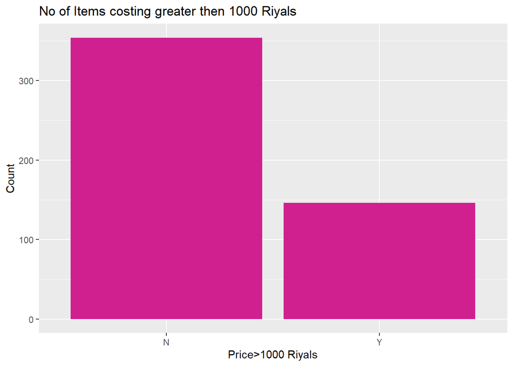

Total Number of Items of Furniture with Price greater than 1000 Riyals.

This table shows how many pieces of furniture are in each category for the data and is then shown as a barchart. It can be seen that the lowest number of furniture items is for Room dividers and the highest is for Chairs. There is a lot of variability in the number of items in each category.

Total number of items of furniture by category

| category | count |
| --- | --- |
| Bar furniture | 8 |
| Beds | 30 |
| Bookcases & shelving units | 71 |
| Cabinets & cupboards | 47 |
| Café furniture | 3 |
| Chairs | 74 |
| Chests of drawers & drawer units | 13 |
| Children’s furniture | 14 |
| Nursery furniture | 18 |
| Outdoor furniture | 33 |
| Room dividers | 1 |
| Sideboards, buffets & console tables | 4 |
| Sofas & armchairs | 51 |
| Tables & desks | 67 |
| Trolleys | 3 |
| TV & media furniture | 27 |
| Wardrobes | 36 |

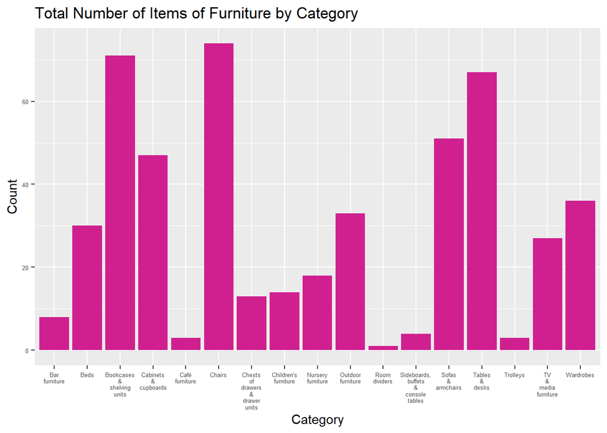

Total Number of Items of Furniture by Category.

The barchart below is showing the total number in each category by if they are priced above or below 1000 Riyals. It shows that some categories have no items priced greater than 1000 Riyals.

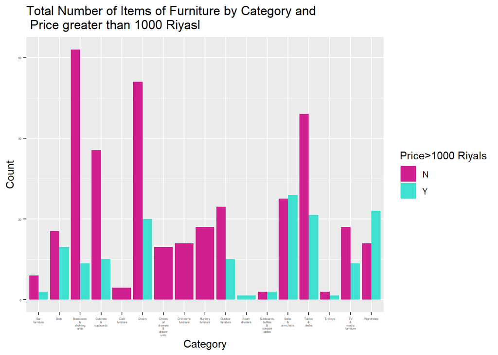

Total Number of Items of Furniture by Category and if they cost greater than 1000 Riyals.

The below plots explore the relationship between some explanatory variables and the price of the item.

The first shows some potential outliers in some categories which are much more expensive than other items in that category.

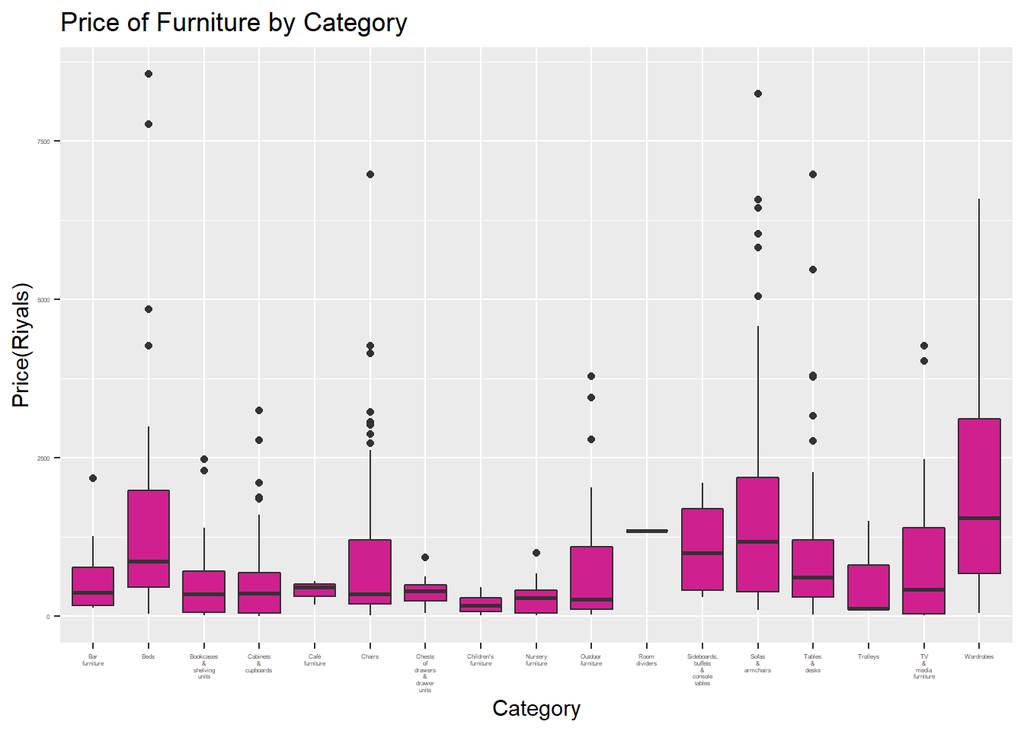

Price of the Item of Furniture by Category.

The box plot below shows whether it is available to buy in other colours and the items price. It appears that the price range for items available in other colours is slightly higher.

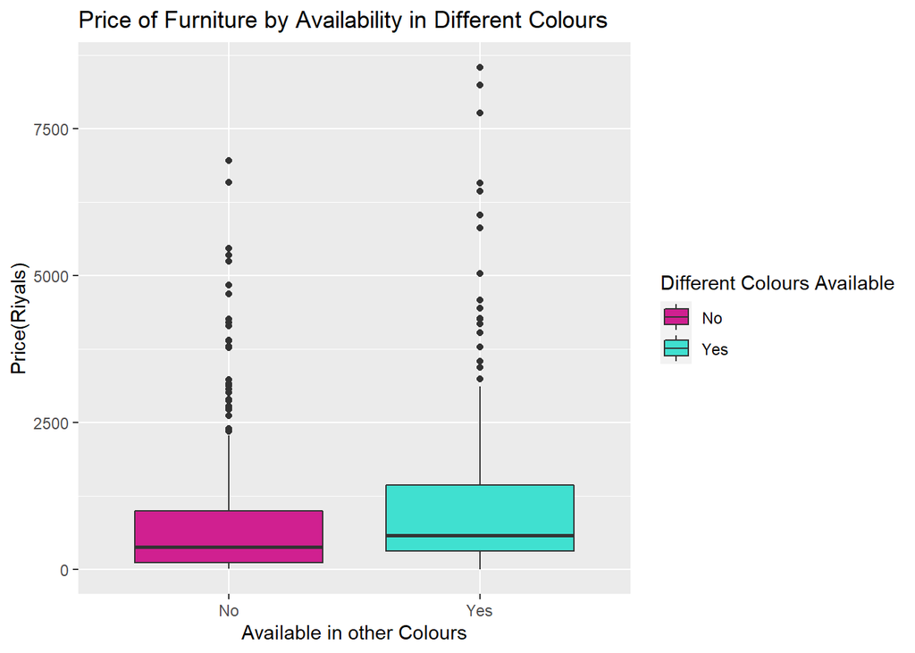

Price of the Item of Furniture by Availability in other Colours.

The below table and plot shows the proportion of items that are available in different colours and costing greater than 1000 Riyals.

```
##  thousandRiyals          No         Yes
##               N 64.1% (227) 35.9% (127)
##               Y 50.0%  (73) 50.0%  (73)
```

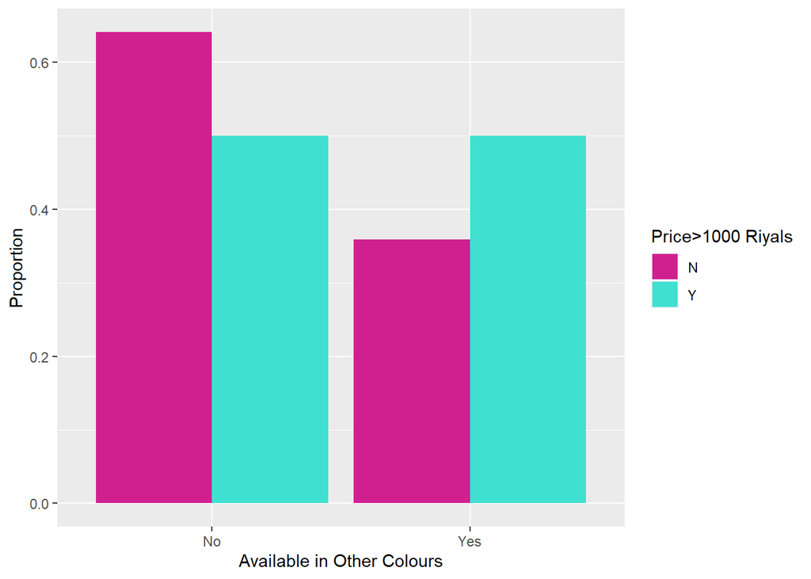

Proportion of Items Availbale in different Colours and if the Price is Greater than 1000 Riyals.

The below table and plot shows the proportion of items available online and costing greater than 1000 Riyals.It shows there is only one item not available online and that it costs more than 1000 Riyals.

```
##  thousandRiyals    FALSE         TRUE
##               N 0.0% (0) 100.0% (354)
##               Y 0.7% (1)  99.3% (145)
```

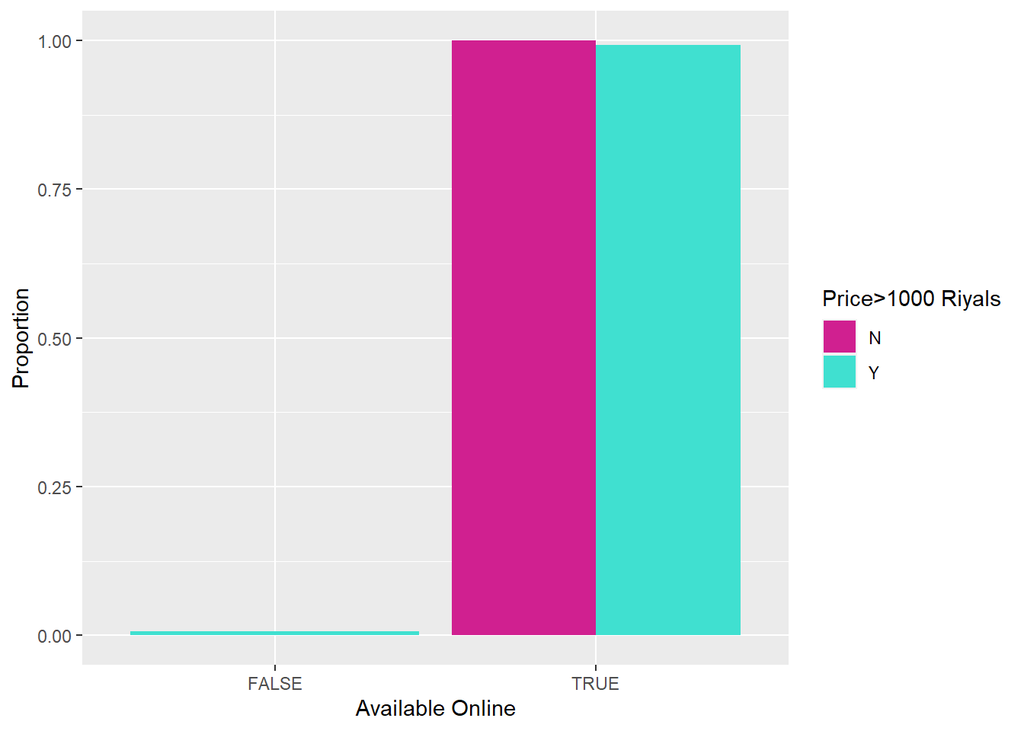

Proportion of Items Availbale in Online and if the Price is Greater than 1000 Riyals.

The next three plots show the height, width and depth of the item of furniture and whether it costs more than 1000 Riyals. These show that the items that cost more than 1000 Riyals have bigger height, width, depth and general size.

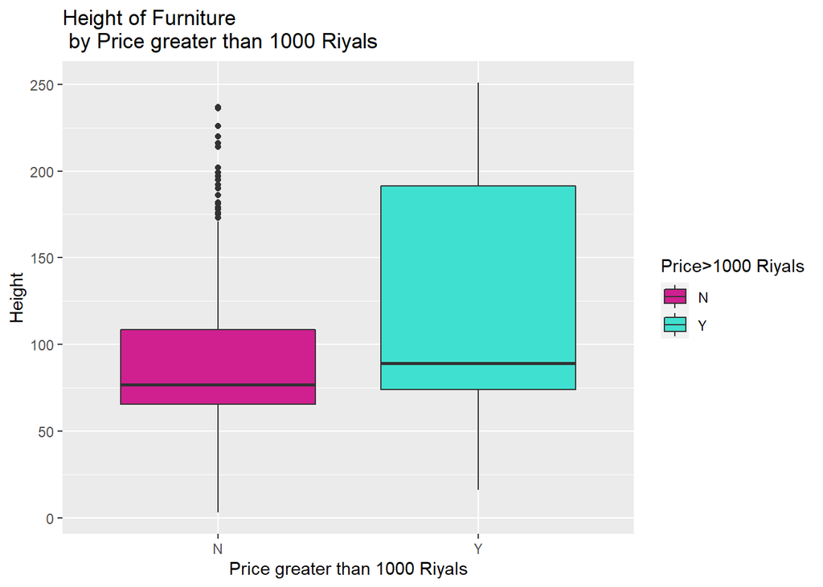

Height of Item by whether the Price is greater than 1000 Riyals.

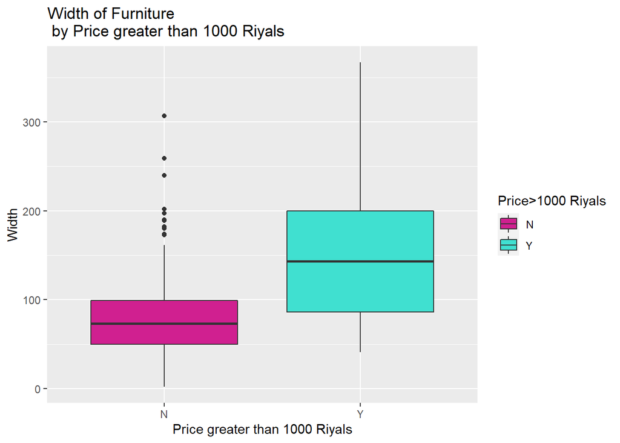

Width of Item by whether the Price is greater than 1000 Riyals.

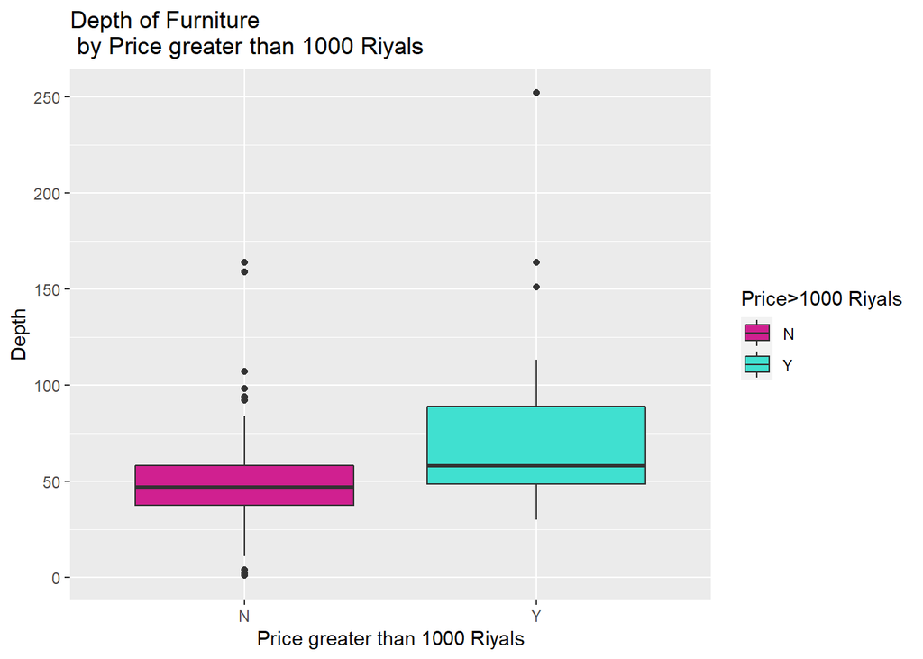

Depth of Item by whether the Price is greater than 1000 Riyals.

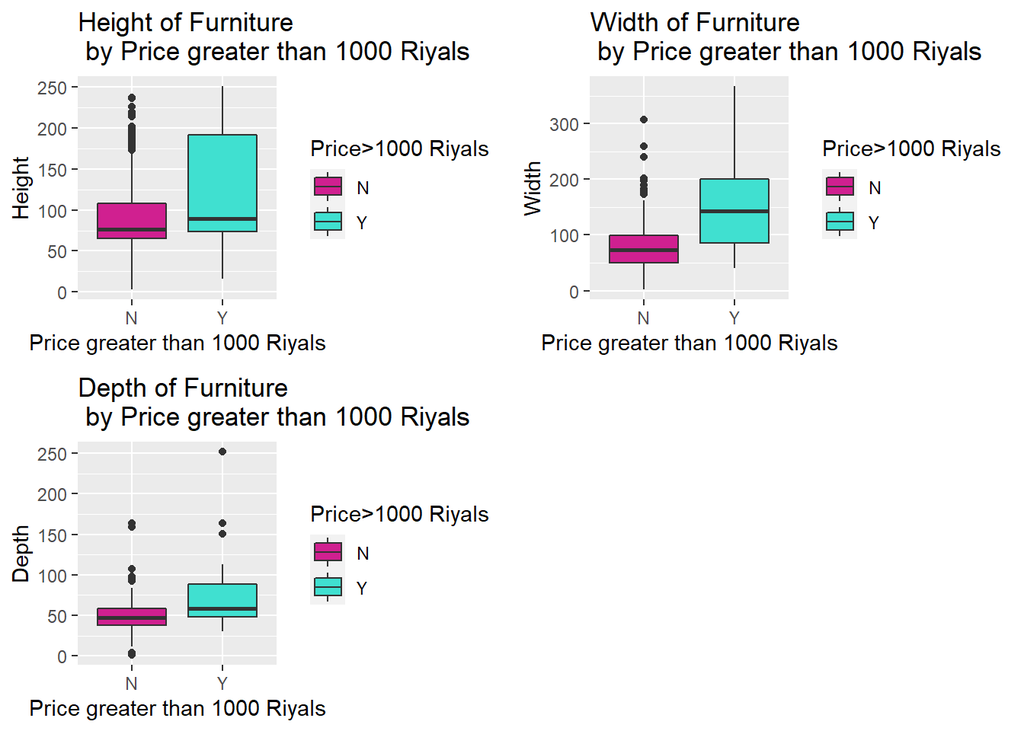

Below are scatter plots showing the price against the height, width and depth of the item of furniture, with the colour showing if the item costs more than 1000 Riyals.

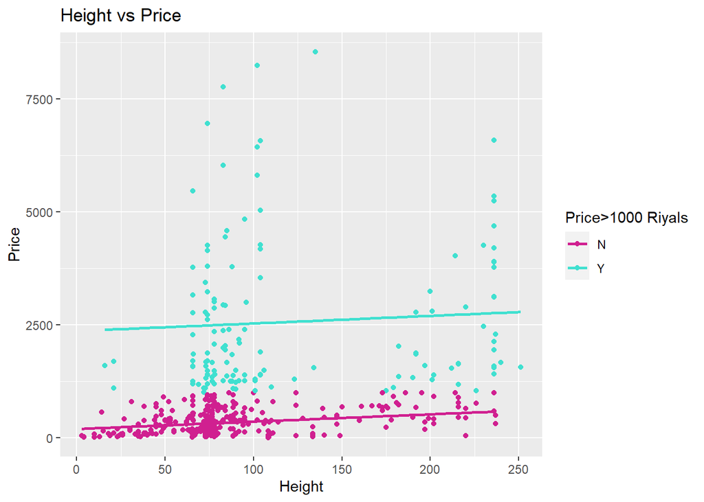

Height of Item against Price.

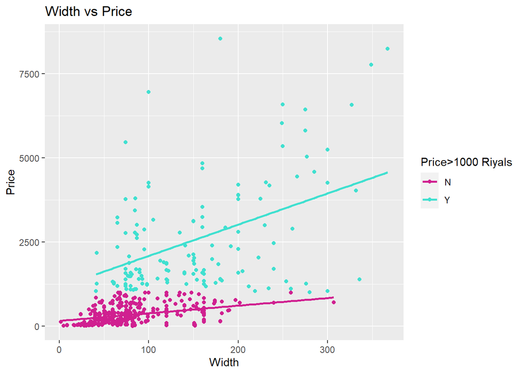

Width of Item against Price.

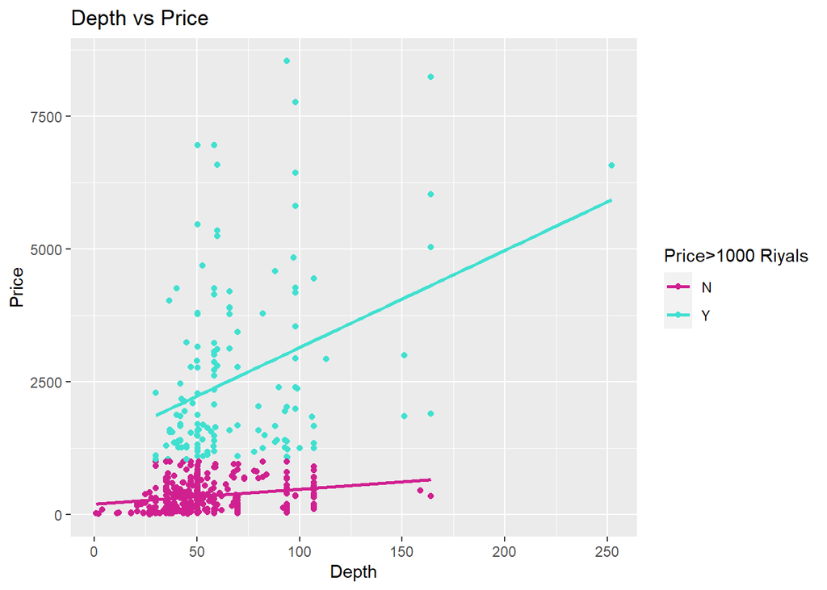

Depth of Item against Price.

# Fitting a Generalised Linear Model

```
## Rows: 500
## Columns: 10
## Groups: category [17]
## $ X               <int> 1, 2, 3, 4, 5, 6, 7, 8, 9, 10, 11, 12, 13, 14, 15, 16,~
## $ item_id         <int> 60406785, 99221446, 29221765, 20403374, 89256262, 5016~
## $ category        <fct> "Chairs", "Tables & desks", "Bookcases & shelving unit~
## $ price           <dbl> 149, 5465, 660, 395, 1895, 375, 150, 375, 995, 400, 18~
## $ sellable_online <fct> TRUE, TRUE, TRUE, TRUE, TRUE, TRUE, TRUE, TRUE, TRUE, ~
## $ other_colors    <fct> No, No, No, Yes, Yes, No, No, No, No, No, Yes, No, Yes~
## $ depth           <dbl> 44.00000, 50.45455, 35.00000, 106.92593, 164.00000, 53~
## $ height          <dbl> 103.00000, 65.65217, 176.00000, 76.59375, 104.00000, 9~
## $ width           <dbl> 52.00000, 74.10909, 86.00000, 161.63636, 117.00000, 52~
## $ thousandRiyals  <fct> N, Y, N, N, Y, N, N, N, N, N, Y, Y, Y, N, N, Y, N, Y, ~
```

## Select input variables to the model

### Analysis of sellable_online and item_id variables

We tried to fit a generalized linear model using categorical explanatory variable sellable_online and binary response variable thousandRiyals to check for any relationship between the two variables. The summary of the data is given by the table below.

Summary of the data.

| sellable_online | N | Y |
| --- | --- | --- |
| FALSE | 0.0% (0) | 100.0% (1) |
| TRUE | 70.9% (354) | 29.1% (145) |

```
##
## Call:
## glm(formula = thousandRiyals ~ sellable_online, family = binomial(link = "logit"),
##     data = data)
##
## Deviance Residuals:
##     Min       1Q   Median       3Q      Max
## -0.8286  -0.8286  -0.8286   1.5722   1.5722
##
## Coefficients:
##                     Estimate Std. Error z value Pr(>|z|)
## (Intercept)            13.57     535.41   0.025    0.980
## sellable_onlineTRUE   -14.46     535.41  -0.027    0.978
##
## (Dispersion parameter for binomial family taken to be 1)
##
##     Null deviance: 603.93  on 499  degrees of freedom
## Residual deviance: 601.47  on 498  degrees of freedom
## AIC: 605.47
##
## Number of Fisher Scoring iterations: 12
```

The model p values for the variable sellable_online was found to be greater than 0.05 and the variable sellable_online was omitted from further analysis.The item_id variable was also omitted from analysis as it only gives the unique identity of the item and does not have statistical significance.

### Selection of variables

We tried different combinations of the variables in the dataset except sellable_online to check for variables appropriate to be included in the model using step function to compare the Akaike information criterion (AIC) values. The combination of variables which gave the lowest AIC value was chosen to be included in the model.

```
## Start:  AIC=403
## thousandRiyals ~ category + other_colors + depth + height + width
##
##                Df Deviance    AIC
## - depth         1   361.01 401.01
## - other_colors  1   361.09 401.09
## <none>              361.00 403.00
## - height        1   388.31 428.31
## - category     16   463.07 473.07
## - width         1   466.89 506.89
##
## Step:  AIC=401.01
## thousandRiyals ~ category + other_colors + height + width
##
##                Df Deviance    AIC
## - other_colors  1   361.11 399.11
## <none>              361.01 401.01
## + depth         1   361.00 403.00
## - height        1   388.77 426.77
## - category     16   474.07 482.07
## - width         1   474.11 512.11
##
## Step:  AIC=399.11
## thousandRiyals ~ category + height + width
##
##                Df Deviance    AIC
## <none>              361.11 399.11
## + other_colors  1   361.01 401.01
## + depth         1   361.09 401.09
## - height        1   388.78 424.78
## - category     16   474.38 480.38
## - width         1   476.02 512.02
```

```
##
## Call:
## glm(formula = thousandRiyals ~ category + height + width, family = binomial(link = "logit"),
##     data = data)
##
## Deviance Residuals:
##     Min       1Q   Median       3Q      Max
## -2.4036  -0.6753  -0.1350   0.2557   2.9258
##
## Coefficients:
##                                                Estimate Std. Error z value
## (Intercept)                                  -4.878e+00  9.979e-01  -4.888
## categoryBeds                                 -2.940e+00  1.083e+00  -2.714
## categoryBookcases & shelving units           -7.349e+00  1.358e+00  -5.414
## categoryCabinets & cupboards                 -2.894e+00  1.026e+00  -2.821
## categoryCafé furniture                       -1.761e+01  3.736e+03  -0.005
## categoryChairs                               -4.754e-01  8.825e-01  -0.539
## categoryChests of drawers & drawer units     -1.795e+01  1.663e+03  -0.011
## categoryChildren's furniture                 -1.848e+01  1.504e+03  -0.012
## categoryNursery furniture                    -1.841e+01  1.393e+03  -0.013
## categoryOutdoor furniture                    -8.598e-01  9.637e-01  -0.892
## categoryRoom dividers                         1.252e+01  6.523e+03   0.002
## categorySideboards, buffets & console tables -1.860e+00  1.602e+00  -1.161
## categorySofas & armchairs                    -2.525e+00  1.043e+00  -2.422
## categoryTables & desks                       -2.582e-01  8.931e-01  -0.289
## categoryTrolleys                              4.862e-01  1.609e+00   0.302
## categoryTV & media furniture                 -4.238e+00  1.196e+00  -3.542
## categoryWardrobes                            -4.691e+00  1.269e+00  -3.696
## height                                        2.480e-02  5.224e-03   4.747
## width                                         3.524e-02  4.659e-03   7.563
##                                              Pr(>|z|)
## (Intercept)                                  1.02e-06 ***
## categoryBeds                                 0.006648 **
## categoryBookcases & shelving units           6.18e-08 ***
## categoryCabinets & cupboards                 0.004787 **
## categoryCafé furniture                       0.996238
## categoryChairs                               0.590098
## categoryChests of drawers & drawer units     0.991389
## categoryChildren's furniture                 0.990196
## categoryNursery furniture                    0.989458
## categoryOutdoor furniture                    0.372339
## categoryRoom dividers                        0.998469
## categorySideboards, buffets & console tables 0.245717
## categorySofas & armchairs                    0.015434 *
## categoryTables & desks                       0.772532
## categoryTrolleys                             0.762468
## categoryTV & media furniture                 0.000397 ***
## categoryWardrobes                            0.000219 ***
## height                                       2.07e-06 ***
## width                                        3.94e-14 ***
## ---
## Signif. codes:  0 '***' 0.001 '**' 0.01 '*' 0.05 '.' 0.1 ' ' 1
##
## (Dispersion parameter for binomial family taken to be 1)
##
##     Null deviance: 603.93  on 499  degrees of freedom
## Residual deviance: 361.11  on 481  degrees of freedom
## AIC: 399.11
##
## Number of Fisher Scoring iterations: 17
```

Using the step function, the variables category, height and width were found to be included in the model for a good fit of data.

## Fit the generalized Linear Model using logit link function

The fitted model is given as follows

$$\begin{equation}
\begin{split}\ln \left(\frac{p}{1-p}\right) &=\alpha+\beta \cdot \text { category }+\gamma \cdot \text{height}+\delta \cdot \text{width} \\&= -4.878-2.94 \cdot \mathbb{I}_{\text {category }} \text { (Beds)}-7.349 \cdot \mathbb{I}_{\text {category }} \text { (Bookcases and shelving units)}-2.894 \cdot \mathbb{I}_{\text {category }} \text { (Cabinets and cupboards)} \\&\quad -17.61 \cdot \mathbb{I}_{\text {category }} \text { (Cafe furniture)} -0.4754\cdot \mathbb{I}_{\text {category }} \text {(Chairs)} -17.95\cdot \mathbb{I}_{\text {category }} \text {(Chests of drawers and rawer units)} \\&\quad -18.48\cdot \mathbb{I}_{\text {category }} \text {(Children’s furniture)}-18.41\cdot \mathbb{I}_{\text {category }} \text {(Nursery furniture )}-0.8598\cdot \mathbb{I}_{\text {category }} \text {(Outdoor furniture)} \\&\quad +12.52\cdot \mathbb{I}_{\text {category }} \text {(Room dividers)}-1.86\cdot \mathbb{I}_{\text {category }} \text {(RSideboards, buffets and console tables)}-2.525\cdot \mathbb{I}_{\text {category }} \text {(Sofas and armchairs)}-0.2582\cdot \mathbb{I}_{\text {category }} \text {(Tables and desks)} \\&\quad +0.4862\cdot \mathbb{I}_{\text {category }} \text {(Trolleys)}-4.238\cdot \mathbb{I}_{\text {category }} \text {(TV and media furniture)}-4.691\cdot \mathbb{I}_{\text {category }} \text {(Wardrobes)}+0.0248\cdot \text{height}+0.03524\cdot \text{width}\end{split}
\end{equation}$$

```
##
## Call:
## glm(formula = thousandRiyals ~ category + height + width, family = binomial(link = "logit"),
##     data = data)
##
## Deviance Residuals:
##     Min       1Q   Median       3Q      Max
## -2.4036  -0.6753  -0.1350   0.2557   2.9258
##
## Coefficients:
##                                                Estimate Std. Error z value
## (Intercept)                                  -4.878e+00  9.979e-01  -4.888
## categoryBeds                                 -2.940e+00  1.083e+00  -2.714
## categoryBookcases & shelving units           -7.349e+00  1.358e+00  -5.414
## categoryCabinets & cupboards                 -2.894e+00  1.026e+00  -2.821
## categoryCafé furniture                       -1.761e+01  3.736e+03  -0.005
## categoryChairs                               -4.754e-01  8.825e-01  -0.539
## categoryChests of drawers & drawer units     -1.795e+01  1.663e+03  -0.011
## categoryChildren's furniture                 -1.848e+01  1.504e+03  -0.012
## categoryNursery furniture                    -1.841e+01  1.393e+03  -0.013
## categoryOutdoor furniture                    -8.598e-01  9.637e-01  -0.892
## categoryRoom dividers                         1.252e+01  6.523e+03   0.002
## categorySideboards, buffets & console tables -1.860e+00  1.602e+00  -1.161
## categorySofas & armchairs                    -2.525e+00  1.043e+00  -2.422
## categoryTables & desks                       -2.582e-01  8.931e-01  -0.289
## categoryTrolleys                              4.862e-01  1.609e+00   0.302
## categoryTV & media furniture                 -4.238e+00  1.196e+00  -3.542
## categoryWardrobes                            -4.691e+00  1.269e+00  -3.696
## height                                        2.480e-02  5.224e-03   4.747
## width                                         3.524e-02  4.659e-03   7.563
##                                              Pr(>|z|)
## (Intercept)                                  1.02e-06 ***
## categoryBeds                                 0.006648 **
## categoryBookcases & shelving units           6.18e-08 ***
## categoryCabinets & cupboards                 0.004787 **
## categoryCafé furniture                       0.996238
## categoryChairs                               0.590098
## categoryChests of drawers & drawer units     0.991389
## categoryChildren's furniture                 0.990196
## categoryNursery furniture                    0.989458
## categoryOutdoor furniture                    0.372339
## categoryRoom dividers                        0.998469
## categorySideboards, buffets & console tables 0.245717
## categorySofas & armchairs                    0.015434 *
## categoryTables & desks                       0.772532
## categoryTrolleys                             0.762468
## categoryTV & media furniture                 0.000397 ***
## categoryWardrobes                            0.000219 ***
## height                                       2.07e-06 ***
## width                                        3.94e-14 ***
## ---
## Signif. codes:  0 '***' 0.001 '**' 0.01 '*' 0.05 '.' 0.1 ' ' 1
##
## (Dispersion parameter for binomial family taken to be 1)
##
##     Null deviance: 603.93  on 499  degrees of freedom
## Residual deviance: 361.11  on 481  degrees of freedom
## AIC: 399.11
##
## Number of Fisher Scoring iterations: 17
```

| Observations | 500 |
| --- | --- |
| Dependent variable | thousandRiyals |
| Type | Generalized linear model |
| Family | binomial |
| Link | logit |

| χ²(18) | 242.82 |
| --- | --- |
| Pseudo-R² (Cragg-Uhler) | 0.55 |
| Pseudo-R² (McFadden) | 0.40 |
| AIC | 399.11 |
| BIC | 479.19 |

|  | Est. | S.E. | z val. | p |
| --- | --- | --- | --- | --- |
| (Intercept) | -4.88 | 1.00 | -4.89 | 0.00 |
| categoryBeds | -2.94 | 1.08 | -2.71 | 0.01 |
| categoryBookcases & shelving units | -7.35 | 1.36 | -5.41 | 0.00 |
| categoryCabinets & cupboards | -2.89 | 1.03 | -2.82 | 0.00 |
| categoryCafé furniture | -17.61 | 3735.58 | -0.00 | 1.00 |
| categoryChairs | -0.48 | 0.88 | -0.54 | 0.59 |
| categoryChests of drawers & drawer units | -17.95 | 1662.79 | -0.01 | 0.99 |
| categoryChildren’s furniture | -18.48 | 1504.30 | -0.01 | 0.99 |
| categoryNursery furniture | -18.41 | 1393.28 | -0.01 | 0.99 |
| categoryOutdoor furniture | -0.86 | 0.96 | -0.89 | 0.37 |
| categoryRoom dividers | 12.52 | 6522.64 | 0.00 | 1.00 |
| categorySideboards, buffets & console tables | -1.86 | 1.60 | -1.16 | 0.25 |
| categorySofas & armchairs | -2.53 | 1.04 | -2.42 | 0.02 |
| categoryTables & desks | -0.26 | 0.89 | -0.29 | 0.77 |
| categoryTrolleys | 0.49 | 1.61 | 0.30 | 0.76 |
| categoryTV & media furniture | -4.24 | 1.20 | -3.54 | 0.00 |
| categoryWardrobes | -4.69 | 1.27 | -3.70 | 0.00 |
| height | 0.02 | 0.01 | 4.75 | 0.00 |
| width | 0.04 | 0.00 | 7.56 | 0.00 |

Standard errors: MLE

```
## Hosmer and Lemeshow Goodness-of-Fit Test
##
## Call:
## glm(formula = thousandRiyals ~ category + height + width, family = binomial(link = "logit"),
##     data = data)
##  ChiSquare df   P_value
##   7.129942  6 0.3089973
```

Hosmer-Lemeshow goodness of fit test was used to test for goodness of model fit.0.3089973 is greater than 0.05, it indicates no lack of fit.